# Phân tích survival trong R

**Biên soạn**

Duc Nguyen | [www.tuhocr.com](https://www.tuhocr.com/)

**Cập nhật**

2025 December 12

[Register](https://www.tuhocr.com/register) [Web](https://class.tuhocr.com/phan_tich_survival_trong_r/)

# 1 Kaplan-Meier

The Kaplan–Meier estimator, also known as the product limit estimator, is a non-parametric statistic used to estimate the survival function from lifetime data.

```r
library(survival)
data(cancer, package="survival")

veteran -> df

df$trt <- factor(df$trt,
                 levels = c(1, 2),
                 labels = c("standard", "test"))

head(df)
```

```
       trt celltype time status karno diagtime age prior
1 standard squamous   72      1    60        7  69     0
2 standard squamous  411      1    70        5  64    10
3 standard squamous  228      1    60        3  38     0
4 standard squamous  126      1    60        9  63    10
5 standard squamous  118      1    70       11  65    10
6 standard squamous   10      1    20        5  49     0
```

```r
fit_1 <- survfit(Surv(time, status == 1) ~ 1,
               data = df,
               stype=1, #kaplan-meier
               ctype = 1,
               conf.type = "log-log"
               )

fit_1
```

```
Call: survfit(formula = Surv(time, status == 1) ~ 1, data = df, stype = 1,
    ctype = 1, conf.type = "log-log")

       n events median 0.95LCL 0.95UCL
[1,] 137    128     80      52     100
```

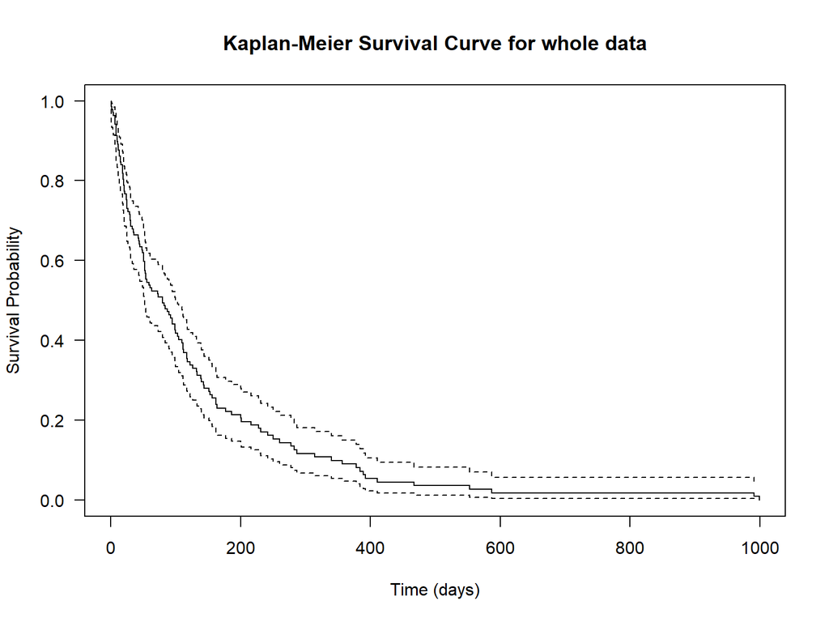

```r
plot(fit_1,
     col = c("black", "black", "black"),
     lty = c(1,2,2),
     las = 1,
     xlab = "Time (days)",
     ylab = "Survival Probability",
     main = "Kaplan-Meier Survival Curve for whole data")
```

```r
fit <- survfit(Surv(time, status == 1) ~ trt,
               data = df,
               stype=1, #kaplan-meier
               ctype = 1,
               conf.type = "log-log"
               )

fit
```

```
Call: survfit(formula = Surv(time, status == 1) ~ trt, data = df, stype = 1,
    ctype = 1, conf.type = "log-log")

              n events median 0.95LCL 0.95UCL
trt=standard 69     64  103.0      54     126
trt=test     68     64   52.5      43      90
```

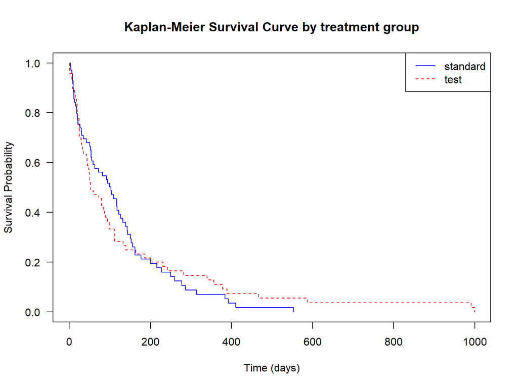

```r
plot(fit,
     col = c("blue", "red"),
     lty = 1:2,
     las = 1,
     xlab = "Time (days)",
     ylab = "Survival Probability",
     main = "Kaplan-Meier Survival Curve by treatment group")

legend("topright",
       legend = levels(df$trt),
       col = c("blue", "red"),
       lty = 1:2)
```

# 2 AFT model

## 2.1 Log-Normal AFT model

### 2.1.1 Interpretation

(Dabney 2025) (phút 14:13)

(Sinha 2024) (trang 14)

$$Y_i = log(T_i) = \beta_0 + X_i^T \beta_1 + U_i$$

where $U_i$ has a known distribution. This model is known as accelerated failure time (AFT) model.

If the distribution of $U$ is assumed to be a known family of distributions, we call it parametric AFT otherwise it is a non-parametric AFT model.

A special case is when $U_i$ is assumed to follow $\texttt{Normal}(0, \sigma)$ distribution, then the distribution of $T_i$ is called lognormal.

```r
library(survival)
data(cancer, package="survival")

veteran$trt <- factor(veteran$trt,
                      levels = c(1, 2),
                      labels = c("standard", "test"))


mod_lnorm <- survreg(Surv(time, status == 1) ~ trt,
                     data = veteran,
                     dist = "lognormal")

summary(mod_lnorm)
```

```
Call:
survreg(formula = Surv(time, status == 1) ~ trt, data = veteran,
    dist = "lognormal")
              Value Std. Error     z       p
(Intercept)  4.2461     0.1677 25.31 < 2e-16
trttest     -0.1777     0.2375 -0.75    0.45
Log(scale)   0.3188     0.0628  5.08 3.9e-07

Scale= 1.38

Log Normal distribution
Loglik(model)= -749.2   Loglik(intercept only)= -749.5
    Chisq= 0.56 on 1 degrees of freedom, p= 0.45
Number of Newton-Raphson Iterations: 2
n= 137
```

This implies an estimated mean log survival time of 4.2461 for the `standard` group; and an estimated mean log $4.2461 + (- 0.177) = 4.0691$ for the `test` group.

p-value = 0.45 > 0.05 it indicates the treatment effect is not statistically significant.

**Note**

Biện luận cho biến liên tục, tham khảo (Breheny 2017) (trang 26)

Ví dụ biến `stage` có hệ số -0.4294, nghĩa là one-uit change in `stage` **shorten** survival time by 35%, vì $e^{-0.4294} = 0.65$, do đó 1 - 0.65 = 0.35.

Ví dụ biến `age` có hệ số +0.4294, nghĩa là one-uit change in `age` **increase** lên survival time by 53.6%, vì $e^{0.4294} = 1.536$, do đó 1.536 - 1 = 0.536.

- **95%CI for $\beta_1$ (coefficient for `trt`)**

$$-0.1777 \pm 1.96 \times 0.2375 = [-0.643, 0.288]$$

```r
beta1_est <- coef(mod_lnorm)["trttest"]

se_beta1 <- summary(mod_lnorm)$table["trttest", "Std. Error"]

ci_beta1 <- beta1_est + c(-1, 1) * 1.96 * se_beta1

ci_beta1
```

```
[1] -0.6431794  0.2877348
```

- **95%CI for $\sigma$ (scale parameter)**

For the scale parameter $\sigma$, we construct a CI on the log-scale:

$$log(1.3755) \pm 1.96 \times 0.0628 \Rightarrow \text{CI for log}(\sigma)=[0.196,0.441]$$

Exponentiating, we obtain the CI for $\sigma$ is $[1.216, 1.556]$

```r
sigma_est <- mod_lnorm$scale

se_sigma <- summary(mod_lnorm)$table["Log(scale)", "Std. Error"]

log_sigma <- log(sigma_est)

ci_log_sigma <- log_sigma + c(-1, 1) * 1.96 * se_sigma

ci_sigma <- exp(ci_log_sigma)

ci_sigma
```

```
[1] 1.216172 1.555714
```

**Note**

Scale parameter $\sigma$, which governs the variability of the log-survival times.

### 2.1.2 Prediction

Using the model-based survival function for the log-Normal AFT model, we compute the estimated survival probabilities at time = 100 for each treatment group.

- For the `standard` group (`trt = 1`):

$$\hat{S}(100| \mathtt{standard}) = 1 - \Phi \bigg(\frac{log(100)- \beta_0}{ \sigma}\bigg) = 1 - \Phi \bigg(\frac{log(100)- 4.2461}{ 1.38 }\bigg) \approx 0.397$$

- For the `test` group (`trt = 2`):

$$\hat{S}(100| \mathtt{test}) = 1 - \Phi \bigg(\frac{log(100)- (\beta_0 + \beta_1)}{ \sigma}\bigg) = 1 - \Phi \bigg(\frac{log(100) - (4.2461 + (-0.1777))}{ 1.38 }\bigg) \approx 0.348$$

```r
beta0 <- coef(mod_lnorm)["(Intercept)"]

beta1 <- coef(mod_lnorm)["trttest"]

sigma_hat <- mod_lnorm$scale

# Compute survival probability at t = 100
t_star <- 100

# Standard treatment group (trt = "standard")
lp_standard <- beta0

S_standard <- 1 - pnorm( (log(t_star) - lp_standard) / sigma_hat)
S_standard
```

```
(Intercept)
  0.3970241
```

```r
# Test treatment group (trt = "test")
lp_test <- beta0 + beta1

S_test <- 1 - pnorm((log(t_star) - lp_test) / sigma_hat)
S_test
```

```
(Intercept)
  0.3481712
```

### 2.1.3 Plot

Plot the fitted survival curves (from the original model) for the two treatment groups on the same graph.

```r
# Extract coefficients and scale
beta0 <- coef(mod_lnorm)["(Intercept)"]
beta1 <- coef(mod_lnorm)["trttest"]
sigma <- mod_lnorm$scale

# Define time grid for plotting
range(veteran$time)
```

```
[1]   1 999
```

```r
t_grid <- seq(0,
              1000,
              length.out = 300)

# Linear predictors for each group
lp_standard <- beta0
lp_test <- beta0 + beta1

# Survival function estimates for each group
S_standard <- 1 - pnorm((log(t_grid) - lp_standard) / sigma)

S_test <- 1 - pnorm((log(t_grid) - lp_test) / sigma)
```

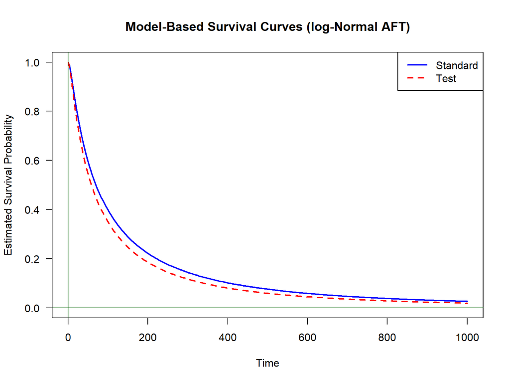

```r
plot(x = t_grid,
     y = S_standard,
     type = "l",
     lwd = 2,
     las = 1,
     col = "blue",
     ylim = c(0, 1),
     xlab = "Time",
     ylab = "Estimated Survival Probability",
     main = "Model-Based Survival Curves (log-Normal AFT)")

lines(x = t_grid,
      y = S_test,
      col = "red",
      lwd = 2,
      lty = 2)

legend("topright",
       legend = c("Standard", "Test"),
       col = c("blue", "red"),
       lwd = 2,
       lty = c(1, 2))

abline(h = 0,
       col = "darkgreen")

abline(v = 0,
       col = "darkgreen")
```

We generated survival curves based on the log-Normal AFT model for both treatment groups over time. The plot above compares estimated survival probabilities for the standard and test groups.

The `standard` group shows slightly higher survival probabilities over time rather than `test` group, though the difference is modest and not statistically significant.

### 2.1.4 Mean and median

#### 2.1.4.1 Mean

`https://stats.stackexchange.com/questions/33664/mean-survival-time-for-a-log-normal-survival-function`

#### 2.1.4.2 Median

## 2.2 Exponential AFT model

### 2.2.1 Interpretation

$$Y_i = log(T_i) = \beta_0 + X_i^T \beta_1 + U_i$$

where random noise $exp(U_i)$ follow the exponential distribution with mean $\lambda_0$.

```r
library(survival)
data(cancer, package="survival")

veteran$trt <- factor(veteran$trt,
                      levels = c(1, 2),
                      labels = c("standard", "test"))


mod_exp <- survreg(Surv(time, status == 1) ~ trt,
                     data = veteran,
                     dist = "exponential")

summary(mod_exp)
```

```
Call:
survreg(formula = Surv(time, status == 1) ~ trt, data = veteran,
    dist = "exponential")
             Value Std. Error     z      p
(Intercept) 4.8214     0.1250 38.57 <2e-16
trttest     0.0928     0.1768  0.53    0.6

Scale fixed at 1

Exponential distribution
Loglik(model)= -751.1   Loglik(intercept only)= -751.2
    Chisq= 0.28 on 1 degrees of freedom, p= 0.6
Number of Newton-Raphson Iterations: 5
n= 137
```

### 2.2.2 Prediction

Using the model-based survival function for the exponential AFT model, we compute the estimated survival probabilities at time = 100 for each treatment group.

For the exponential AFT model, the survival functions is

$$S(t|x) = exp(-t \times exp(-\eta))$$

where $\eta = \beta_0 + \beta_1 x$

Using the estimated coefficients:

$\hat{S}(100|\texttt{standard}) = exp(-100 \times exp(- 4.8214)) = 0.4468$

$\hat{S}(100|\texttt{test}) = exp(-100 \times exp(- 4.8214 - 0.0928)) = 0.4799$

Both groups have survival probabilities at time 100 just below 0.50, with the `test` group slightly higher.

```r
# Extract estimated coefficients
beta0_exp <- coef(mod_exp)["(Intercept)"]
beta1_exp <- coef(mod_exp)["trttest"]

# Compute linear predictor for each group
lp_standard <- beta0_exp # trt = "standard"
lp_test <- beta0_exp + beta1_exp # trt = "test"

# Compute survival probability at time = 100
t0 <- 100

S_standard <- exp( -t0 * exp(-lp_standard) )

S_standard
```

```
(Intercept)
  0.4468474
```

```r
S_test <- exp( -t0 * exp(-lp_test) )

S_test
```

```
(Intercept)
  0.4799308
```

**Tính CI**

```r
# Covariance matrix of estimated coefficients
V <- vcov(mod_exp)
V
```

```
            (Intercept)   trttest
(Intercept)    0.015625 -0.015625
trttest       -0.015625  0.031250
```

```r
# Estimated beta vector
beta_hat <- coef(mod_exp) # Named vector

# Define function to compute CI for S(t | x) (slides 25{26)
CI_S_exp <- function(x_star, t0 = 100, beta_hat, V) {

# a = (1, x*)
a <- c(1, x_star)
# Linear predictor
eta_hat <- sum(a * beta_hat)
# Variance of eta_hat = a^T V a
var_eta <- as.numeric(t(a) %*% V %*% a)
se_eta <- sqrt(var_eta)
# CI for eta
ci_eta <- eta_hat + c(-1.96, 1.96) * se_eta
# CI for S(t | x) = exp( -t * exp(-eta) )
S_hat <- exp( -t0 * exp(-eta_hat) )
ci_S <- exp( -t0 * exp(-ci_eta) ) # Note: reversed direction due to exp(-eta)
return(list(S_hat = S_hat, CI = ci_S))

}
# Compute CIs

CI_standard <- CI_S_exp(x_star = 0, #trt = standard (ref level)
                        t0 = 100,
                        b = beta_hat,
                        V = V)
CI_standard
```

```
$S_hat
[1] 0.4468474

$CI
[1] 0.3573025 0.5323265
```

```r
CI_test <- CI_S_exp(x_star = 1, #trt = test
                    t0 = 100,
                    b = beta_hat,
                    V = V)
CI_test
```

```
$S_hat
[1] 0.4799308

$CI
[1] 0.3914416 0.5629335
```

### 2.2.3 Mean and median

```r
# Design matrix rows for standard and test treatment groups
x_std <- c(1, 0) # intercept + trt = standard (ref level)

x_test <- c(1, 1) # intercept + trt = test
```

#### 2.2.3.1 Mean

```r
# Function to compute estimate and CI for mean survival time
mean_surv_ci <- function(x_vec, V, b) {
eta <- sum(x_vec * b)
se_eta <- drop(sqrt(t(x_vec) %*% V %*% x_vec))
ci_eta <- eta + c(-1, 1) * qnorm(0.975) * se_eta
est <- exp(eta)
ci <- exp(ci_eta)
return(list(estimate = est, CI = ci))
}
```

```r
mean_std <- mean_surv_ci(x_std, V, beta_hat)
mean_std
```

```
$estimate
[1] 124.1406

$CI
[1]  97.16587 158.60399
```

```r
mean_test <- mean_surv_ci(x_test, V, beta_hat)
mean_test
```

```
$estimate
[1] 136.2187

$CI
[1] 106.6195 174.0352
```

#### 2.2.3.2 Median

```r
# Function to compute estimate and CI for median survival time
median_surv_ci <- function(x_vec, V, b) {
eta <- sum(x_vec * b)
se_eta <- drop(sqrt(t(x_vec) %*% V %*% x_vec))
ci_eta <- eta + c(-1, 1) * qnorm(0.975) * se_eta
est <- log(2) * exp(eta)
ci <- log(2) * exp(ci_eta)
return(list(estimate = est, CI = ci))
}
```

```r
median_std <- median_surv_ci(x_std, V, beta_hat)
median_std
```

```
$estimate
[1] 86.04772

$CI
[1]  67.35025 109.93591
```

```r
median_test <- median_surv_ci(x_test, V, beta_hat)
median_test
```

```
$estimate
[1] 94.41964

$CI
[1]  73.90302 120.63200
```

## 2.3 Weibull AFT model

### 2.3.1 Interpretation

$$Y_i = log(T_i) = \beta_0 + X_i^T \beta_1 + U_i$$

where $\epsilon_i = exp(U_i)$ follows the Weibull distribution with the scale $b$ and shape $a$.

```r
library(survival)
data(cancer, package="survival")

veteran$trt <- factor(veteran$trt,
                      levels = c(1, 2),
                      labels = c("standard", "test"))


mod_weib <- survreg(Surv(time, status == 1) ~ trt,
                     data = veteran,
                     dist = "weibull")

summary(mod_weib)
```

```
Call:
survreg(formula = Surv(time, status == 1) ~ trt, data = veteran,
    dist = "weibull")
             Value Std. Error     z      p
(Intercept) 4.7697     0.1479 32.25 <2e-16
trttest     0.0478     0.2079  0.23  0.818
Log(scale)  0.1585     0.0673  2.35  0.019

Scale= 1.17

Weibull distribution
Loglik(model)= -748.1   Loglik(intercept only)= -748.1
    Chisq= 0.05 on 1 degrees of freedom, p= 0.82
Number of Newton-Raphson Iterations: 5
n= 137
```

The estimated coefficient for `trttest` is 0.048, which is not statistically significant (p-value = 0.818).

### 2.3.2 Prediction

```r
# Extract estimated shape
ahat <- 1 / mod_weib$scale
# Extract coefficients
b0 <- mod_weib$coefficients[1]
b1 <- mod_weib$coefficients[2]
# Define covariates: x = 0 (control), x = 1 (treatment)
x_std <- 0
x_test <- 1
# Target time t
t0 <- 100
```

```r
# Compute estimated survival probabilities at t = 100
S_std <- exp(- (t0 * exp(-b0 - x_std * b1))^ahat)
S_std
```

```
(Intercept)
  0.4193591
```

```r
S_test <- exp(- (t0 * exp(-b0 - x_test * b1))^ahat)
S_test
```

```
(Intercept)
  0.4341928
```

### 2.3.3 Mean and median

#### 2.3.3.1 Mean

```r
# Extract model coefficients
b0 <- mod_weib$coef[1]
b1 <- mod_weib$coef[2]
# Weibull shape parameter
a_hat <- 1 / mod_weib$scale
# x-values for groups
x_std <- 0
x_test <- 1
# Mean survival time: exp(lp) * Gamma(1 + 1/a)
mean_std <- exp(b0 + x_std * b1) * gamma(1 + 1/a_hat)
mean_std
```

```
(Intercept)
   127.9294
```

```r
mean_test <- exp(b0 + x_test * b1) * gamma(1 + 1/a_hat)
mean_test
```

```
(Intercept)
   134.1975
```

#### 2.3.3.2 Median

```r
med_std <- exp(b0 + x_std * b1) * (log(2))^(1/a_hat)
med_std
```

```
(Intercept)
   76.72239
```

```r
med_test <- exp(b0 + x_test * b1) * (log(2))^(1/a_hat)
med_test
```

```
(Intercept)
   80.48154
```

# 3 Cox PH model

```r
library(survival)
sim_ph <- read.csv("HW_6_data_1.csv")

head(sim_ph)
```

```
       time status trt  age
1  6.689445      1   1 70.2
2  6.835349      1   0 41.5
3 32.835707      1   1 56.0
4  2.053170      1   0 47.2
5  8.651760      1   1 74.1
6  6.525246      1   1 75.7
```

```r
# Convert treatment to factor (with meaningful labels)

sim_ph$trt <- factor(sim_ph$trt,
                     levels = c(0, 1),
                     labels = c("Control", "Treatment"))
```

$$\lambda(t|X) = \lambda_0(t)exp(X' \beta)$$

$$log(\lambda(t|x_i)) = log(\lambda_0(t)) + \beta_1 trt_i + \beta_2 age_i$$

```r
fit_1 <- coxph(Surv(time, status == 1) ~ trt + age,
               data = sim_ph)

summary(fit_1)
```

```
Call:
coxph(formula = Surv(time, status == 1) ~ trt + age, data = sim_ph)

  n= 200, number of events= 193

                  coef exp(coef)  se(coef)      z Pr(>|z|)
trtTreatment -0.727337  0.483194  0.153839 -4.728 2.27e-06 ***
age           0.033869  1.034449  0.006292  5.383 7.33e-08 ***
---
Signif. codes:  0 '***' 0.001 '**' 0.01 '*' 0.05 '.' 0.1 ' ' 1

             exp(coef) exp(-coef) lower .95 upper .95
trtTreatment    0.4832     2.0696    0.3574    0.6532
age             1.0344     0.9667    1.0218    1.0473

Concordance= 0.649  (se = 0.022 )
Likelihood ratio test= 43.58  on 2 df,   p=3e-10
Wald test            = 43.15  on 2 df,   p=4e-10
Score (logrank) test = 44.29  on 2 df,   p=2e-10
```

The coefficient for `trtTreatment` is −0.727, corresponding to a hazard ratio of $exp(−0.727) \approx 0.483$. This means that, holding `age` constant, participants in the `Treatment` group have about 48.3% the hazard of participants in the `Control` group; i.e., they are less likely to experience the event at any given time point. The effect is statistically significant.

**Note**

If `trtTreatment` is 0.727, corresponding to a hazard ratio of $exp(0.727) \approx 2.06$. This means that: holding `age` constant, participants in the `Treatment` group have about 2.06 times the hazard of participants in the `Control` group; i.e., `Treatment` group are MUCH likely to experience the event at any given time point in comparison to `Control` group.

The coefficient for `age` is 0.0339, corresponding to a hazard ratio of $exp(0.0339) \approx 1.034$. This implies that, holding `trt` group constant, each additional year of age is associated with a 1.034 - 1 = 0.034 = 3.4 % increase in the hazard of experiencing the event. The effect is statistically significant.

## 3.1 PH assumptions

### 3.1.1 Graphical approach

#### 3.1.1.1 Biến phân loại

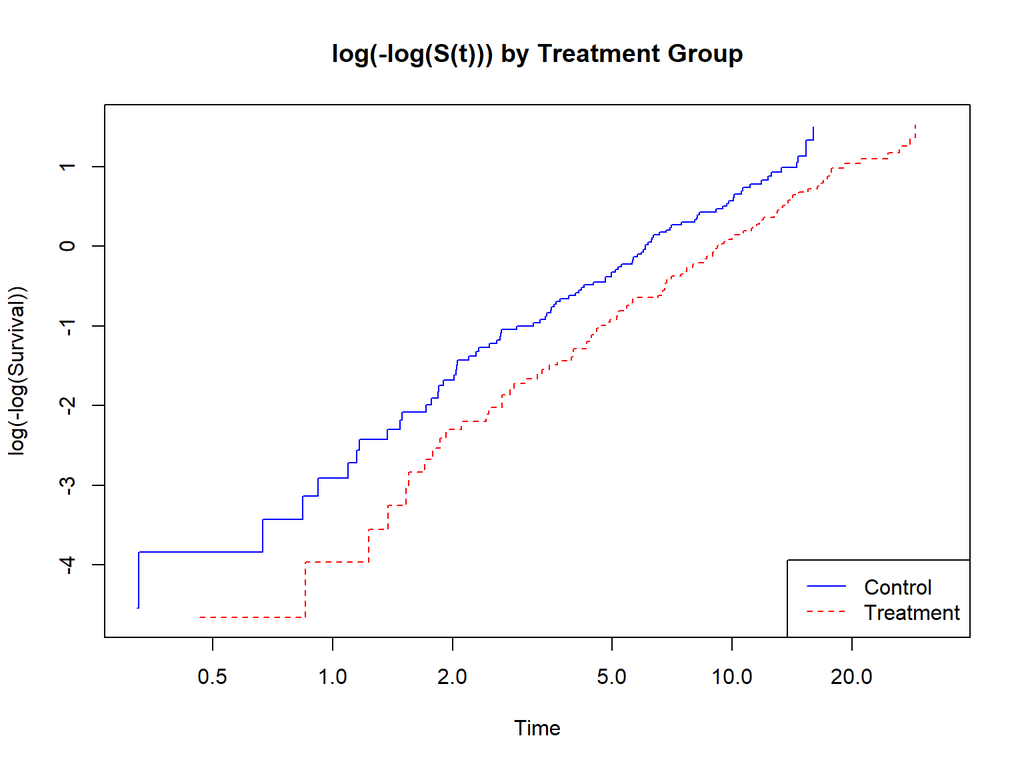

```r
km_trt <- survfit(Surv(time, status == 1) ~ trt,
                  data = sim_ph)

plot(km_trt,
     fun = "cloglog",
     col = c("blue", "red"),
     lty = 1:2,
     xlab = "Time",
     ylab = "log(-log(Survival))",
     main = "log(-log(S(t))) by Treatment Group")

legend("bottomright",
       legend = levels(sim_ph$trt),
       col = c("blue", "red"),
       lty = 1:2)
```

Since the two curves for `trt` appear approximately separated by a constant amount, the PH assumption appears (based on this graphical check) to be reasonable with respect to `trt`.

#### 3.1.1.2 Biến liên tục

```r
sim_ph$age_bin <- cut(sim_ph$age,
                      breaks = c(0, 50, 60, 70, 100),
                      include.lowest = FALSE,
                      right = TRUE,
                      labels = c("(0,50]",
                                 "(50,60]",
                                 "(60,70]",
                                 "(70,100]")
                      )
```

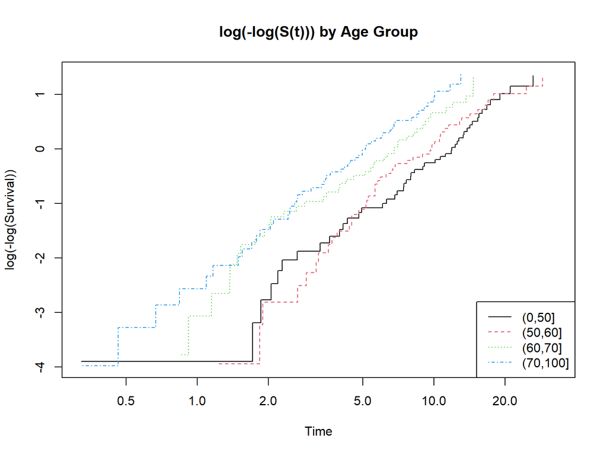

```r
km_age <- survfit(Surv(time, status == 1) ~ age_bin,
                  data = sim_ph)

plot(km_age,
     fun = "cloglog",
     col = 1:4,
     lty = 1:4,
     xlab = "Time",
     ylab = "log(-log(Survival))",
     main = "log(-log(S(t))) by Age Group")

legend("bottomright",
       legend = levels(sim_ph$age_bin),
       col = 1:4,
       lty = 1:4)
```

### 3.1.2 Hypothesis testing approach

H0: proportional hazards assumption is reasonable

H1: proportional hazards assumption is NOT hold

The p-value for `trt` is high, as expected, confirming our conclusion regarding the PH assumption with respect to `trt`.

The p-value for `age` is smaller but still reasonably high, supporting the PH assumption with respect to `age`.

```r
cox.zph(fit_1)
```

```
         chisq df    p
trt    0.00126  1 0.97
age    1.56091  1 0.21
GLOBAL 1.59721  2 0.45
```

## 3.2 Baseline cumulative hazard

Baseline cumulative hazard function $\Lambda_0(t)$

```r
basehaz_df <- basehaz(fit_1)
```

```r
survfit_obj <- survfit(fit_1)

surv_df <- data.frame(
time = survfit_obj$time,
surv = survfit_obj$surv
)

surv_df$neglogsurv <- -log(surv_df$surv)
```

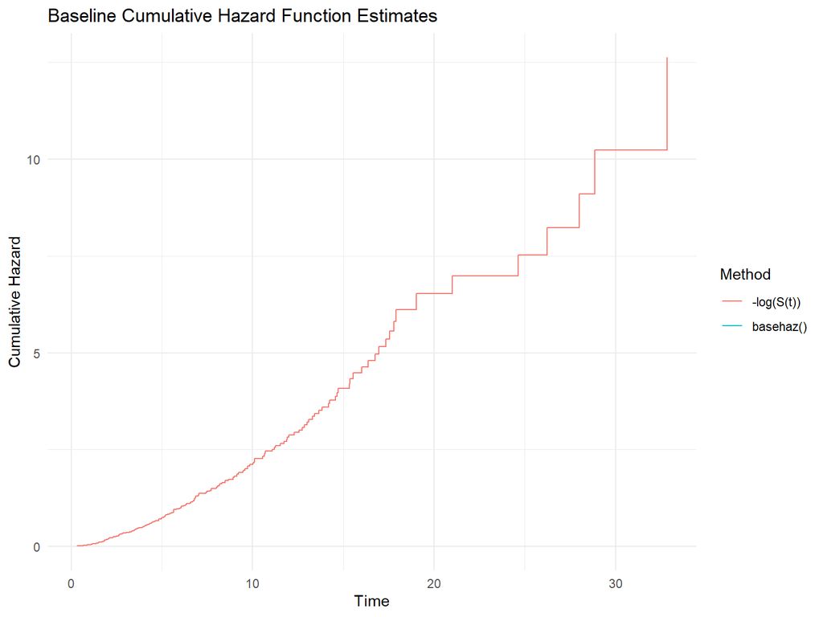

```r
library(ggplot2)

ggplot() +

geom_step(data = basehaz_df,
          aes(x = time,
              y = hazard,
              color = "basehaz()")) +

  geom_step(data = surv_df,
            aes(x = time,
                y = neglogsurv,
                color = "-log(S(t))")) +

  labs(title = "Baseline Cumulative Hazard Function Estimates",
       x = "Time",
       y = "Cumulative Hazard",
       color = "Method") +
theme_minimal()
```

## 3.3 Prediction

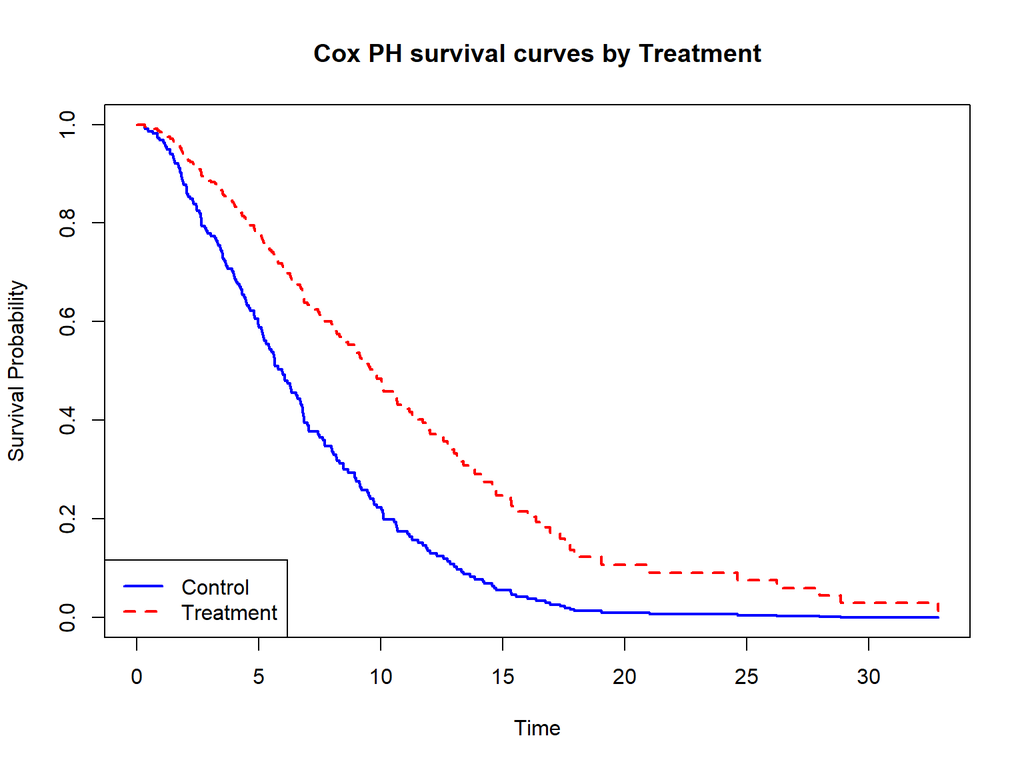

```r
newdata_50 <- data.frame(
  trt = factor(c("Control", "Treatment")),
  age = c(50, 50)
)


fit_surv <- survfit(fit_1,
                    newdata = newdata_50,
                    se.fit = F)

plot(fit_surv,
     col = c("blue", "red"),
     lty = 1:2,
     lwd = 2,
     xlab = "Time",
     ylab = "Survival Probability",
     main = "Cox PH survival curves by Treatment")

legend("bottomleft",
       legend = c("Control", "Treatment"),
       col = c("blue", "red"),
       lty = 1:2,
       lwd = 2)
```

The model-based survival curves suggest that survival prognosis (for a 50-year old) is better in the `Treatment` group than in the `Control` group.

## 3.4 Likelihood ratio test

```r
fit_reduced <- coxph(Surv(time, status) ~ trt, data = sim_ph)

fit_full <- coxph(Surv(time, status) ~ trt * age, data = sim_ph)

# Likelihood ratio test comparing the two models
anova(fit_reduced, fit_full)
```

```
Analysis of Deviance Table
 Cox model: response is  Surv(time, status)
 Model 1: ~ trt
 Model 2: ~ trt * age
   loglik  Chisq Df Pr(>|Chi|)
1 -820.80
2 -806.12 29.359  2  4.215e-07 ***
---
Signif. codes:  0 '***' 0.001 '**' 0.01 '*' 0.05 '.' 0.1 ' ' 1
```

The LR test, based on 2 degrees of freedom, results in a test statistic value of 29.359 and a tiny p-value. This indicates that $age$ and the $trt \times age$ interaction terms contribute substantially to model fit quality.

## 3.5 Wald test

```r
beta_hat <- coef(fit_full)

V <- vcov(fit_full)
# Define matrix A, compute Wald statistic and p-value.

A <- matrix(c(1, 0, 40,
              1, 0, 60),
            nrow = 2,
            byrow = TRUE)

A_beta <- A %*% beta_hat

A_V_A_t <- A %*% V %*% t(A)

W <- t(A_beta) %*% solve(A_V_A_t) %*% A_beta

W
```

```
        [,1]
[1,] 23.0937
```

```r
df <- nrow(A)

p_value <- pchisq(W, df = df, lower.tail = FALSE)

p_value
```

```
            [,1]
[1,] 9.66643e-06
```

$$log(\lambda(t|x_i)) = log(\lambda_0(t)) + \beta_1 trt_i + \beta_2 age_i + \beta_3(trt \times age)_i$$

$$\begin{array}{r}
\text{Treatment effect for 40 years old: } \\
\text{log harzard: trt = 1, age = 40: constant} + \beta_1 + 40 \beta_2 + 40 \beta_3 \\
-\text{log harzard: trt = 0, age = 40: constant} ~~~~~~~~~+ 40 \beta_2~~~~~~~~~~~~~\\
\hline \color{Red}{1}\color{Black} \beta_1 +~~ \color{Red}{0} \color{Black}\beta_2 + \color{Red}{40} \color{Black} \beta_3
\end{array}$$

Giả thuyết:

$H_0: A \beta = 0$ meaning Treatment effect at age 40 is NO effect. There is no different between `Treatment` and `Control`. In short, no treatment effect at age 40

$H_1: A \beta \ne 0$ meaning Treatment effect at age 40 EXIST effect. There is different between `Treatment` and `Control`. In short, EXIST treatment effect at age 40.

Tương tự cho age 60.

# 4 Tài liệu tham khảo

1. `Goel, Manish Kumar et al. "Understanding survival analysis: Kaplan-Meier estimate." International journal of Ayurveda research vol. 1,4 (2010): 274-8. doi:10.4103/0974-7788.76794`
2. `https://www.bookdown.org/rwnahhas/RMPH/survival-phassumption.html`
3. `https://www.graphpad.com/guides/prism/latest/statistics/stat_the_hazard_ratio.htm`

## References

Breheny, Patrick. 2017. “Accelerated Failure Time Models.” http://163.61.73.72/tree/survival/breheny_aft.pdf.

Dabney, Alan. 2025. “STAT 645 - Lecture 29.” http://163.61.73.72/tree/survival/stat645_lecture29.mp4.

Sinha, Samiran. 2024. “Survival Analysis: Parametric Analysis.” http://163.61.73.72/tree/survival/survival_part2.pdf.